# Bayesian Information Borrowing with Applications in Clinical Trials

2025-10-22

# 1 Introduction

本文旨在完善Bayesian统计在临床试验中应用时涉及的算法，所考虑的先验仅包括混合先验和幂先验。章节2简介混合先验及幂先验信息借用的统计学理论。章节3讨论混合先验和幂先验信息借用在SAP模板的各主要终点中的应用。章节4将基于`rstan`实现混合先验及幂先验信息借用在实际数据中的应用，通过不同场景下的模拟案例，就参数估计和假设检验，比较不同类型的先验下，频率学派方法、混合先验信息借用和幂先验信息借用的统计性能。

# 2 Method and Notation

令$D$表示分析数据，$D_{hst}$表示历史数据，$\theta$表示模型参数，$w\in [0, 1]$表示混合先验的权重参数或幂先验的温度参数。令$D=(Y, A, Z)$分别表示分析数据的结局、治疗分组和协变量，$D_{hst}=(Y_{hst}, A_{hst}, Z_{hst})$分别表示历史数据的结局、治疗分组和协变量，$1\leq i\leq n$表示第i个个体。$p_{hst}(\theta|D_{hst})$表示信息先验。

## 2.1 混合先验信息借用

混合先验将信息先验$p_{hst}(\theta|D_{hst})$和模糊先验$\pi_{vag}(\theta)$按一定的权重混合，其中，$\pi_{vag}(\theta)$通常取弱信息共轭先验（如对二分类终点，可取Jeffreys’ prior；对其他终点可取unit information prior）(Kass and Wasserman 1995; Schmidli et al. 2014)，
$$\begin{equation}
p_{mp}(\theta|w) \propto wp_{hst}(\theta|D_{hst})+(1-w)\pi_{vag}(\theta). \tag{2.1}
\end{equation}$$

若无法确定$w$的值，可将$w$也看作随机变量，此时将由数据自适应决定权重分配，然而，将$w$看作随机变量并不等同于dynamically borrowing (Yang et al. 2023)，
$$\begin{equation}
p_{mp}(\theta,w)\propto\left(wp_{hst}(\theta|D_{hst})+(1-w)\pi_{vag}(\theta)\right)\pi(w). \tag{2.2}
\end{equation}$$

除了式(2.1)和(2.2)的两种方法以外，还有 Yang et al. (2023) 提出的动态信息借用的混合先验self-adapting mixture prior (SAM prior)，同时，他们在文章中指出混合先验(2.2)的统计性能并不好：*In addition, we investigate three alternative approaches: (a) a fully Bayesian approach by assigning $w$ a uniform prior … none of these approaches perform well.* 此外，也有相关的材料指出$w\sim Unif(0, 1)$时fully Bayesian approach的推断结果与$w=0.5$相近。

## 2.2 幂先验信息借用

幂先验的表达式如下：
$$p_{pp}(\theta|w) \propto L(\theta|D_{hst})^w\pi_0(\theta).$$
从表达式不难得出，当$w=0$时，幂先验不借用历史数据$D_{hst}$；当 $w=1$时，幂先验完全借用历史数据$D_{hst}$。幂先验的一个重要性质为当$\pi_0(\theta)$为proper prior时，幂先验也是proper prior (Ibrahim et al. 2015)。

同样地，若无法确定$w$的值，幂先验也可将$w$也看作随机变量，此时有
$$\begin{equation}
p_{pp}(\theta,w)\propto L(\theta|D_{hst})^w\pi_0(\theta)\pi(w).\tag{2.3}
\end{equation}$$

然而，与混合先验不同的是，若不对信息先验$L(\theta|D_{hst})^w\pi_0(\theta)$标准化，该幂先验会违背Likelihood Principle (Robert 2007; Berry et al. 2010)：当历史数据相同时，对历史数据取不同的充分统计量，得到的先验分布也会不同，因而会产生不同的推断结果。因此，在将$w$看作随机变量时，需要进行如下标准化，
$$\begin{equation}
p_{npp}(\theta,w)=p_{pp}(\theta|w)\pi(w)=\frac{L(\theta|D_{hst})^w\pi_0(\theta)}{\int L(\theta|D_{hst})^w\pi_0(\theta)d\theta}\pi(w).\tag{2.4}
\end{equation}$$
经过标准化的幂先验(2.4)又称为NPP (Normalized power prior) 或MPP (Modified power prior)(Ibrahim et al. 2015; Banbeta et al. 2019)。对于initial prior $\pi_0(\theta)$的选择，从后验的收敛角度考虑，建议$\pi_0(\theta)$取proper prior。

NPP中的标准化项$C(w)=\int L(\theta|D_{hst})^w\pi_0(\theta)d\theta$通常没有显式表达式，因此常使用积分近似，具体的算法主要包括以下几类：

- Laplace approximation
- Monte Carlo Metropolis-Hastings (MCMH) algorithm (Liang and Jin 2013)
- Path sampling (Friel and Pettitt 2008; Ye et al. 2022)

由于$w$取值较小时，使用Laplace approximation可能会有较大偏差，本文档仅介绍后两种方法。使用MH算法从NPP相应的后验分布中抽样时，主要困难在于rejection的步骤中，比值$C(w)/C(w^\prime)$无法计算。基于MCMH算法，一种可行的方法是在MH算法中嵌入以下近似：
$$\frac{C(w)}{C(w^\prime)}=\frac{\int L(\theta|D_{hst})^w\pi_0(\theta)d\theta}{\int L(\theta|D_{hst})^{w^\prime}\pi_0(\theta)d\theta}=\int\frac{L(\theta|D_{hst})^w\pi_0(\theta)}{L(\theta|D_{hst})^{w^\prime}\pi_0(\theta)}\cdot\frac{L(\theta|D_{hst})^{w^\prime}\pi_0(\theta)}{\int L(\theta|D_{hst})^{w^\prime}\pi_0(\theta)d\theta}d\theta=\lim_{M\to\infty}\frac{1}{M}\sum_{i=1}^M\frac{L(\theta_i|D_{hst})^w}{L(\theta_i|D_{hst})^{w^\prime}}, a.s.,$$
其中$\theta_i\sim p_{pp}(\theta|w^\prime)\propto L(\theta|D_{hst})^{w^\prime}\pi_0(\theta)$。因此，我们可以通过MCMC算法抽取足够多的$\theta_i$来计算$C(w)/C(w^\prime)$。

Path sampling算法主要基于 Friel and Pettitt (2008) 的如下结果

$$\log C(w)=\int_0^wE_{p_{pp}(\theta|w^\ast)}[l(\theta|D_{hst})]dw^\ast,$$
其中$p_{pp}(\theta|w^\ast)\propto L(\theta|D_{hst})^{w^\ast}\pi_0(\theta)$。因此，通过先在$[0, 1]$区间划分$K$个网格，对于每一个网格端点$w_k$，使用MCMC算法从$p_{pp}(\theta|w_k)$分布对$\theta$抽样，可以近似$E_{p_{pp}(\theta|w_k)}[l(\theta|D_{hst})]$，最后基于网格和近似得到的期望可以近似计算$\log C(w)$。具体算法如下 (Ye et al. 2022)：

- Step 0: Choose a set of $K−1$ different numbers as knots between 0 and 1, and another knot at 1, with $K$ sufficiently large. Sort them in ascending order $(w_1, . . . , w_{K−1}, 1)$. Let $w_0 = 0$, $\Delta_1 = w_1, \Delta_i = w_i−w_{i−1} (1 < i ≤ K),\text{ and }\Delta_K = 1−w_{K−1}$. Choose $M$, the number of MCMC samples in a run when sampling from $p_{pp}(\theta|w)$. Initialize $l = 1$.
- Step 1: Generate $M$ samples from $p_{pp}(\theta|w_l)$ using an appropriate MCMC algorithm. Denote the sample as $(\theta_l^{(1)},\theta_l^{(2)},\dots,\theta_l^{(M)})$.
- Step 2: Calculate $h(w_l) = \sum^M_{j=1}l(\theta_l^{(j)}|D_{hst})/M$.
- Step 3: Calculate $\log C(w_l) ≈ \sum^l_{k=1} \Delta_k\{h(w_{k−1}) + h(w_k)\}$ (the Trapezoidal rule).
- Step 4: Increase $l$ by 1. If $l \leq n$ then repeat Steps 1 to 3.

相较于MCMH算法，path sampling在`stan`中易于实现。此外，MCMH算法在每次从proposal distribution抽样时，都要再嵌套一层MCMC抽样来计算acceptance ratio；而path sampling算法可以独立于MH算法给出所有的$\log C(w_l)$，因此计算效率远高于MCMH算法。综合考虑，尽管MCMH算法可能更加精准和稳定，本文优先使用path sampling实现NPP方法。

Neuenschwander, Branson, and Spiegelhalter (2009) 指出unnormalized power prior (2.3)在某些情况下不适用（如在估计rate时对$w$的选择会趋于0）。Hobbs et al. (2011) 指出NPP没有直接将历史数据和新数据间的可比性参数化，并且无论是unnormalized power prior还是NPP，往往都倾向于衰减$w$：*A problem with modified joint power priors is that they do not directly parameterize the commensurability of the historical and new data… Furthermore, Neelon and O’Malley (2010) caution against using Ibrahim–Chen and MPPs because they both tend to overattenuate the impact of the historical data, forcing the use of fairly large $\alpha_0$ (or in our case, fairly informative hyperpriors for $\alpha_0$) to deliver sufficient borrowing.* 同时，他们也给出了新的幂先验方法commensurate power prior (CPP)来解决上述问题。本文暂不考虑CPP方法的应用。

## 2.3 有效历史样本量

指南中提到“对于借用信息所代表的样本量，应进行充分评估，例如使用有效样本量”。借用信息的有效样本量在评估不同类型先验对历史数据的借用程度时，起到关键作用。Hobbs, Carlin, and Sargent (2013) 基于参数的后验方差给出了有效历史样本量EHSS (Effective Historical Sample Size)的近似,

$$EHSS_w(\theta)\approx n_{cur}\left(\frac{Var(\theta|w=0,D)}{Var(\theta|w,D,D_{hst})}-1\right),$$

其中，$Var(\theta|w=0,D)$为不进行信息借用时，$\theta$的后验方差，$Var(\theta|w,D,D_{hst})$为在$w$下进行信息借用时，$\theta$的后验方差。该近似适用范围广泛，可用于各种不同统计模型，且后验方差可以直接从MCMC抽样中计算，计算过程简洁。

## 2.4 Remark

无论是混合先验，还是幂先验，需要明确研究中的目标参数。若冗余参数取值在历史数据和分析数据中相近，此时将冗余参数也纳入信息先验中，会导致在随机权重的模型中，赋予历史数据的权重膨胀，从而增加目标参数的估计偏差。因此，一般不建议将冗余参数也纳入信息先验，而是像 Hobbs et al. (2011) 文中通过极大似然估计等替代历史数据中的冗余参数。

# 3 Application

## 3.1 连续变量终点

### 3.1.1 ANCOVA模型

ANCOVA的模型假设如下：
$$Y_i=\alpha+\tau A_i+Z_i^T\gamma+\varepsilon_i, \varepsilon_i\sim N(0, \sigma^2).$$
也即，
$$Y\sim N(X\beta, \sigma^2I),$$
其中$X=[1, A, Z]\in\mathbb{R}^{n\times p}$，$\beta = [\alpha, \tau, \gamma^T]^T$。

对于历史数据，有$\hat\beta_{hst}\sim N(\beta,\sigma^2(X^TX)^{-1})$。将历史模型中的nuisance parameter $\sigma^2$用MLE或无偏估计代入（本文使用无偏估计），得到混合先验为
$$p_{mp}(\tau|w)\sim wN(\hat{\tau}_{hst},\hat\sigma_{\tau}^2)+(1-w)\pi_{vag}(\tau).$$

对于$\pi_{vag}(\tau)$的选取，可用unit information prior $\pi_{vag}(\tau)=N(\hat\tau_{hst},n\hat\sigma_{\tau}^2)$。此外，对于当前模型中的nuisance parameter $\alpha,\gamma,\sigma^2$，则使用Jeffreys’ prior。

幂先验为
$$p_{pp}(\beta,\sigma^2|w)\propto (\sigma^2)^{-\frac{nw}{2}}\exp\left\{-\frac{1}{2}(\sigma^2/w)^{-1}(Y_{hst}-X_{hst}\beta)^T(Y_{hst}-X_{hst}\beta)\right\}\pi_0(\theta).$$
同样使用无偏估计代入$\sigma^2$，此时幂先验可表示为
$$p_{pp}(\tau|w)\propto N\left(\hat\tau_{hst},w^{-1}\hat\sigma_{\tau}^2\right)\pi_0(\tau).$$
从该表达式也可看出，当温度$w$增加时，将借用更多的历史信息，而当温度$w$降低时，幂先验的密度将会趋于平坦，从而趋近无信息先验。在后续的模拟研究中，出于对后验收敛性的考虑，取幂先验的initial prior为
$$\pi_0(\tau)=\pi_{vag}(\tau)=N(\hat\tau_{hst},n\hat\sigma_{\tau}^2).$$

对于当前模型的nuisance parameter，同样使用Jeffreys’ prior处理。

此时若考虑$w$为随机变量，则
$$\begin{equation}
\log C(w)=const-\frac{w}{2}\log(2\pi\hat\sigma_{\tau}^2)-\frac{1}{2}\log w+\log N(\hat\tau_{hst};\hat\tau_{hst},(w^{-1}+n)\hat\sigma_{\tau}^2).\tag{3.1}
\end{equation}$$

## 3.2 二分类变量终点

对于二分类变量终点，假设一共有$K$个分层因素，对于第$k$个分层因素，有$N_k$个参与者，其中治疗组人数为$n_{1+k}$，有$n_{11k}$人发生事件，对照组人数为$n_{2+k}$，有$n_{21k}$人发生事件（如表3.1所示）。

Table 3.1: The structure of $2\times 2\times K$ table.

| Treatment | Success | Failure | Total |
| --- | --- | --- | --- |
| 1 | $n_{11k}$ | $n_{12k}$ | $n_{1+k}$ |
| 0 | $n_{21k}$ | $n_{22k}$ | $n_{2+k}$ |
| Total | $n_{+1k}$ | $n_{+2k}$ | $N_{k}$ |

### 3.2.1 Common odds ratio的Mantel-Haenszel估计

对于$2\times2\times K$的分层列联表，OR的Mantel-Haenszel估计为
$$\hat\theta_{MH}=\frac{\sum_kn_{11k}n_{22k}/n_{++k}}{\sum_kn_{12k}n_{21k}/n_{++k}}=\frac{\sum_kn_{++k}p_{11|k}p_{22|k}}{\sum_kn_{++k}p_{12|k}p_{21|k}},$$

令$\hat\theta_{MH}=R/S=\sum_kR_k/\sum_kS_k$，$\log\hat\theta_{MH}$的方差估计为
$$\hat\sigma^2[\log\hat\theta_{MH}]=\frac{1}{2R^2}\sum_k\frac{(n_{11k}+n_{22k})R_k}{n_{++k}}+\frac{1}{2S^2}\sum_k\frac{(n_{12k}+n_{21k})S_k}{n_{++k}}+\frac{1}{2RS}\sum_k\frac{(n_{11k}+n_{22k})S_k+(n_{12k}+n_{21k})R_k}{n_{++k}}.$$

对于历史数据，有$(\log\hat\theta_{MH,hst}-\log\theta)/\sigma[\log\hat\theta_{MH,hst}]\overset{d}{\to}N(0, 1)$。将方差估计代入，得到混合先验为
$$p_{mp}(\log\theta|w)\sim wN(\log\hat{\theta}_{MH,hst},\hat\sigma^2[\log\hat\theta_{MH,hst}])+(1-w)\pi_{vag}(\log\theta).$$

其中$\pi_{vag}(\log\theta)=N(\log\hat\theta_{MH,hst},n\hat\sigma^2[\log\hat\theta_{MH,hst}])$。

对于当前研究的数据，假设所有层的OR都相同，即
$$\theta=\frac{p_{1+|k}/(1-p_{1+|k})}{p_{2+|k}/(1-p_{2+|k})},\forall k,$$
且$n_{11k}$和$n_{21k}$服从如下二项分布
$$n_{11k}\sim Bin(n_{1+k},p_{1+|k}),n_{21k}\sim Bin(n_{2+k},p_{2+|k}),$$
那么$n_{11k}$的对数条件似然可表示为
$$l(\theta|n_{11k},n_{+1k},n_{1+k},n_{2+k})=\sum_kn_{11k}\log\theta-\sum_k\log Z_k(\theta)+const,$$
其中$Z_k(\theta)=\sum_{i=L_k}^{U_k}\begin{pmatrix}n_{1+k}\\i\end{pmatrix}\begin{pmatrix}n_{2+k}\\n_{+1k}-i\end{pmatrix}\theta^i$，$L_k=\max(0, n_{+1k}-n_{2+k}), U_k=\min(n_{+1k},n_{1+k})$.

# 4 Simulation Study

## 4.1 连续变量终点

对于连续变量终点，为简化问题，设定如下数据生成过程：

$$Y_{i}-Y_i^{baseline}=\alpha+(\tau_0+\delta I(i\in D))A_{i}+\gamma Y_{i}^{baseline}+\varepsilon_{i},\\
Y_i^{baseline}\overset{i.i.d.}{\sim}N(0, \sigma_Y^2),\\
\varepsilon_{i}\overset{i.i.d.}{\sim}N(0, \sigma^2).$$

其中，参数$\tau_0$为历史数据的治疗效应，$\tau=\tau_0+\delta$为当前研究的治疗效应，$|\delta|$衡量当前研究的数据与历史数据间的data conflict大小。当前研究的样本量$n=56$，历史数据的样本量$n_{hst}=100$，治疗组和对照组的比例为$1:1$。对于参数，取$\alpha=0.5, \tau_0 = 0.6, \gamma = 0.1, \sigma_Y = 0.5$，$\sigma$的选取满足$Var(Y_i)=1$，此时对应ANCOVA的$R^2=0.13$，在单侧$\alpha=0.025$时检验$\tau>0$的power约为0.8。模拟研究的第一部分以0.05为步长将$\delta$从-0.6递增至0来评估prior-data conflict下各方法的表现。

```r
# --- Sample size estimation ---
library(pwrss)
gamma <- 0.1
sd_baseline <- 0.5
power.t.regression(beta = 0.6, sd.predictor = 0.5, sd.outcome = sqrt(1+gamma^2*sd_baseline^2-(1+gamma)^2*sd_baseline^2), k.total = 2, power = 0.8, alpha = 0.025, alternative = "one.sided")
```

```
## +--------------------------------------------------+
## |             SAMPLE SIZE CALCULATION              |
## +--------------------------------------------------+
##
## Linear Regression Coefficient (T-Test)
##
## ---------------------------------------------------
## Hypotheses
## ---------------------------------------------------
##   H0 (Null Claim) : beta - null.beta <= 0
##   H1 (Alt. Claim) : beta - null.beta >  0
##
## ---------------------------------------------------
## Results
## ---------------------------------------------------
##   Sample Size            = 56  <<
##   Type 1 Error (alpha)   = 0.025
##   Type 2 Error           = 0.194
##   Statistical Power      = 0.806
```

- 场景一：type I error随$w$的变化，历史数据治疗效应$\tau_0=0.6$，当前研究无治疗效应；
- 场景二：power随$w$的变化，历史数据和当前研究治疗效应均为$0.6$，但入组困难，power仅能达到0.7；
- 场景三：power随$w$的变化，历史数据的治疗效应$\tau_0=0.6$，但场景二对疗效过于乐观，当前研究实际治疗效应为$\tau=0.5$，此时power仅能达到0.527。

场景二对应的样本量为

```r
# --- Sample size estimation ---
library(pwrss)
gamma <- 0.1
sd_baseline <- 0.5
power.t.regression(beta = 0.6, sd.predictor = 0.5, sd.outcome = sqrt(1+gamma^2*sd_baseline^2-(1+gamma)^2*sd_baseline^2), k.total = 2, power = 0.7, alpha = 0.025, alternative = "one.sided")
```

```
## +--------------------------------------------------+
## |             SAMPLE SIZE CALCULATION              |
## +--------------------------------------------------+
##
## Linear Regression Coefficient (T-Test)
##
## ---------------------------------------------------
## Hypotheses
## ---------------------------------------------------
##   H0 (Null Claim) : beta - null.beta <= 0
##   H1 (Alt. Claim) : beta - null.beta >  0
##
## ---------------------------------------------------
## Results
## ---------------------------------------------------
##   Sample Size            = 44  <<
##   Type 1 Error (alpha)   = 0.025
##   Type 2 Error           = 0.299
##   Statistical Power      = 0.701
```

场景三对应的power为

```r
# --- Sample size estimation ---
power.t.regression(beta = 0.5, sd.predictor = 0.5, sd.outcome = sqrt(1+gamma^2*sd_baseline^2-(1+gamma)^2*sd_baseline^2), k.total = 2, n=44, alpha = 0.025, alternative = "one.sided")
```

```
## +--------------------------------------------------+
## |                POWER CALCULATION                 |
## +--------------------------------------------------+
##
## Linear Regression Coefficient (T-Test)
##
## ---------------------------------------------------
## Hypotheses
## ---------------------------------------------------
##   H0 (Null Claim) : beta - null.beta <= 0
##   H1 (Alt. Claim) : beta - null.beta >  0
##
## ---------------------------------------------------
## Results
## ---------------------------------------------------
##   Sample Size            = 44
##   Type 1 Error (alpha)   = 0.025
##   Type 2 Error           = 0.473
##   Statistical Power      = 0.527  <<
```

最后，为了探索数据分析阶段，如何基于先验参数$w$进行敏感性分析，将基于上述三个场景生成三组模拟数据，通过改变先验参数$w$，进行phase change分析。

### 4.1.1 ANCOVA模型

ANCOVA模型的模拟研究考虑以下几种信息先验方法：

1. Fixed mixture prior (FMP) with $w=0.5$ and $\pi_{vag}(\tau)=N(\hat\tau_{hst},n\hat\sigma_{\tau}^2),\pi_0(\alpha,\gamma,\sigma^2)\propto 1/\sigma^2$;
2. Random mixture prior (RMP) with $w\sim Beta(1, 1)$ and $\pi_{vag}(\tau)=N(\hat\tau_{hst},n\hat\sigma_{\tau}^2),\pi_0(\alpha,\gamma,\sigma^2)\propto 1/\sigma^2$;
3. Fixed power prior (FPP) with $w=0.5$ and $\pi_0(\tau)=\pi_{vag}(\tau),\pi_0(\alpha,\gamma,\sigma^2)\propto 1/\sigma^2$;
4. Unnormalized power prior (UPP) with $w\sim Beta(1, 1)$ and $\pi_0(\tau)=\pi_{vag}(\tau),\pi_0(\alpha,\gamma,\sigma^2)\propto 1/\sigma^2$;
5. Normalized power prior (ANPP) with $w\sim Beta(1, 1)$ and $\pi_0(\tau)=\pi_{vag}(\tau),\pi_0(\alpha,\gamma,\sigma^2)\propto 1/\sigma^2$ using path sampling;
6. Normalized power prior (NPP) with $w\sim Beta(1, 1)$ and $\pi_0(\tau)=\pi_{vag}(\tau),\pi_0(\alpha,\gamma,\sigma^2)\propto 1/\sigma^2$ using exact $\log C(w)$ based on (3.1);
7. ANCOVA with current data.

在模拟研究中，对于点估计和区间估计，比较bias、RMSE、credible/confidence interval (CI) length和coverage probability (CP)；对于假设检验，比较type I error和power，其中Bayes方法在$P(\tau>0|D,D_{hst})>0.975$时拒绝原假设（等价于$\tau$的95%可信区间下界大于0）。

#### 4.1.1.1 试运行结果展示

以下给出ANPP和NPP方法在一组示例模拟数据上的试运行结果（$\delta=0$，也即没有prior-data conflict），其中`beta[3]`为治疗效应，`sigma2`为残差方差$\sigma^2$，`w_eff`为权重或温度。图4.1和4.2展示试运行结果的MCMC算法收敛情况（trace plot通过比较各个chain的抽样分布来检查收敛性，pair plot中若出现黄色和红色的散点则需要注意抽样的收敛性，在一些hierarchical models可能会出现以上问题，此时应通过non-centered parameterization处理模型）：

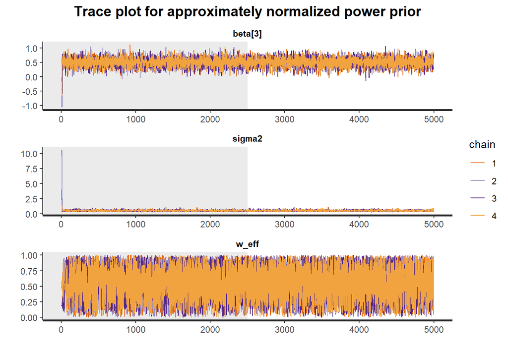

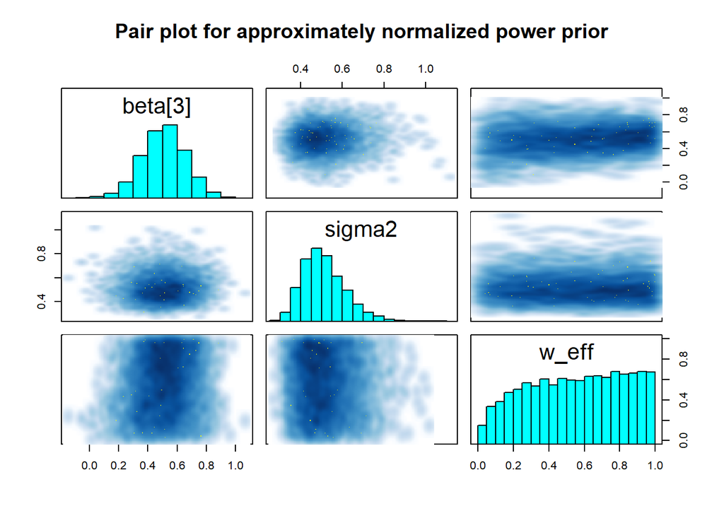

Figure 4.1: Trace and pair plots of the posterior samples of treatment effect, residual variance, and temperature under the approximately normalized power prior using path sampling. The shaded region in trace plots marks burn-in. MCMC ran with 4 chains and 5,000 iterations per chain.

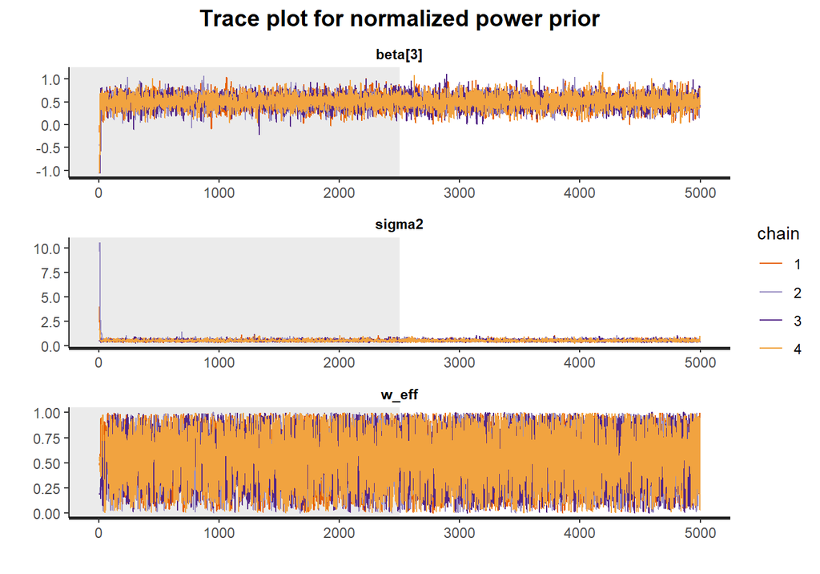

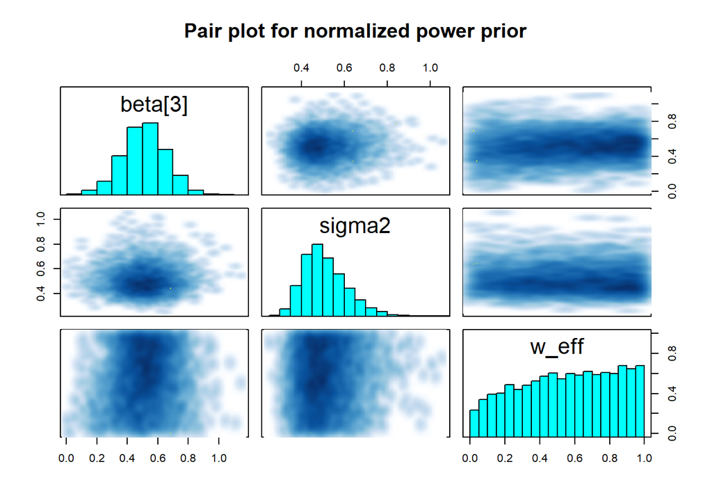

Figure 4.2: Trace and pair plots of the posterior samples of treatment effect, residual variance, and temperature under the normalized power prior. The shaded region in trace plots marks burn-in. MCMC ran with 4 chains and 5,000 iterations per chain.

下表比较了ANPP、NPP和仅使用ANCOVA时的分析结果，可以看到ANPP和NPP相较于ANCOVA有更短的可信区间。

Table 4.1: Overall comparison of results from the Bayesian models and ANCOVA. There is no prior-data conflict in this example. The point estimate and 95% credible/confidence interval for treatment effect and weight/temperature parameter are shown in the last two columns.

[output not shown]

下图比较了使用path sampling近似的$\log C(w)$和基于式(3.1)的$\log C(w)$。

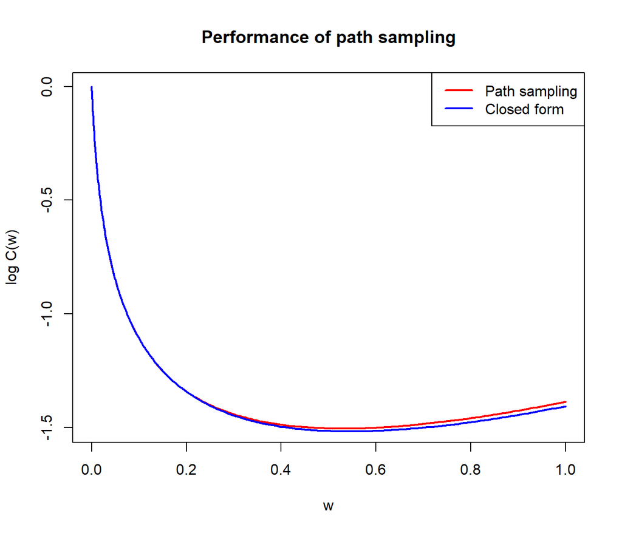

Figure 4.3: Comparison of the path sampling approximated normalization constant (red) and the closed-form normalization constant (blue).

#### 4.1.1.2 统计性能比较

本节比较prior-data conflict的程度变化时各方法的统计性能，历史数据的治疗效应为0.6，当前研究的治疗效应（current effect size）从0增加至0.6。每个current effect size下的模拟次数为1,000次。

图4.4展示了FMP ($w=0.5$), RMP, FPP ($w=0.5$), UPP, ANPP, NPP, ANCOVA七种方法的bias和RMSE随current effect size的变化。图4.5展示了各方法的probability of rejection随current effect size的变化，其中，当$\tau=0$时，probability of rejection即为type I error。对于probability of rejection的计算，ANCOVA方法使用单侧t-检验来检验$H_0:\tau=0\text{ v.s. }H_1:\tau>0$，其他的贝叶斯方法使用10,000次MCMC抽样的后验概率$P(\tau\gt 0|D, D_{hst})\gt 0.975$来检验。注意到由于模拟次数为1,000次，$\alpha=0.025$下type I error的95%可能范围约为0.015至0.035，power的95%可能范围约为0.775至0.825。对于各方法统计性能的比较主要有以下结果：

1. 所有信息借用的方法在无prior-data conflict下bias与RMSE最低，且type I error均膨胀；
2. $w=0.5$时的FMP和RMP的表现几乎相同，验证了Methods部分对混合先验的讨论；
3. $w=0.5$时的FPP的bias在强prior-data conflict下最高，且type I error最高；
4. UPP的bias在强prior-data conflict下低于NPP方法，RMSE在弱prior-data conflict下高于NPP方法;
5. ANPP和NPP的表现几乎相同，表明path sampling的近似对后验估计和推断几乎没有影响；
6. 由于ANCOVA方法不借用任何信息，其bias均在0附近，但是RMSE在弱prior-data conflict场景下要高于其他信息借用方法；ANCOVA方法的probability of rejection则符合预设的$\alpha$和power。

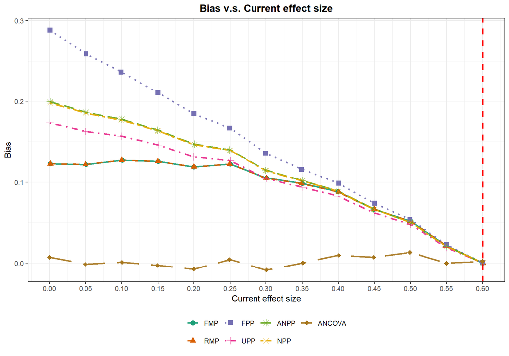

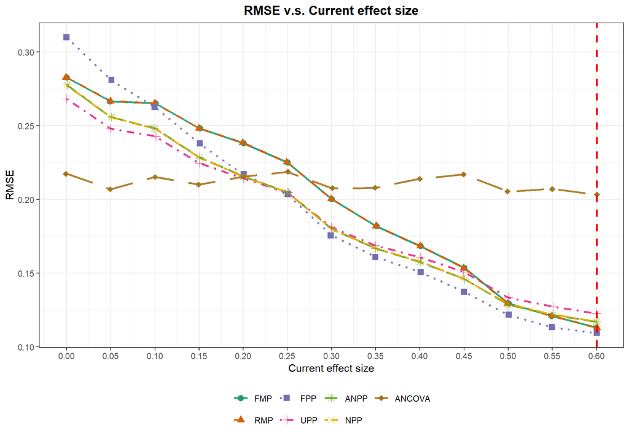

Figure 4.4: Bias and RMSE of the compared methods under various current effect size. The historical effect size is $\tau_0=0.6$, which is indicated by the vertical red dashed line. The strength of prior-data conflict reduces as current effect size $\tau$ increases from 0 to 0.6. Bias and RMSE are estimated based on 1,000 simulation datasets.

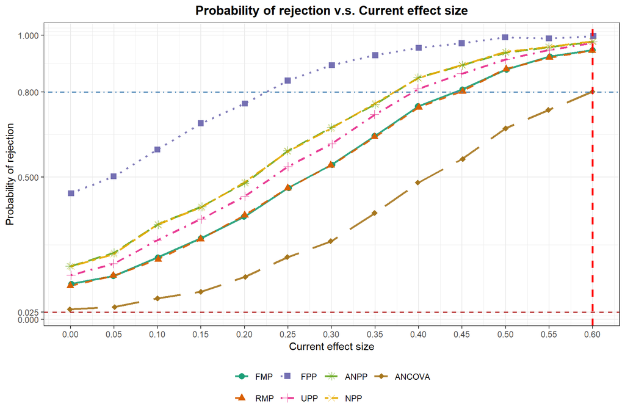

Figure 4.5: Probability of rejection of the compared methods under various current effect size. The historical effect size is $\tau_0=0.6$, which is indicated by the vertical red dashed line. The strength of prior-data conflict reduces as current effect size $\tau$ increases from 0 to 0.6. Note that when $\tau=0$, the probability of rejection is actually the type I error. Reference lines indicate the nominal significance level $\alpha=0.025$ and the pre-defined power of 0.8 when $\tau=0.6$. For ANCOVA, the null hypothesis $H_0:\tau=0$ is tested with right-tailed t-test at the level of 0.025, while for Bayesian methods, the null hypothesis is tested by $P(\tau\gt 0|D, D_{hst})\gt 0.975$ with 10,000 MCMC iterations. Probability of rejection is estimated based on 1,000 simulation datasets.

表4.2展示了上述方法的bias, RMSE, CI length, coverage probability, probability of rejection和$\hat{R}$在1,000次模拟试验中的具体数值，其中$\hat{R}$是用于检查MCMC抽样是否收敛的统计量，$\hat{R}>1.01$表明MCMC抽样的收敛可能存在问题。

Table 4.2: Statistical performance of the compared methods under various current effect size. Confidence/Credible intervals are derived at the level of 95%. For ANCOVA, the null hypothesis $H_0:\tau=0$ is tested with right-tailed t-test at the level of 0.025, while for Bayesian methods, the null hypothesis is tested by $P(\tau\gt 0|D, D_{hst})\gt 0.975$ with 10,000 MCMC iterations. All metrics are estimated based on 1,000 simulation datasets.

| Historical effect size | Current effect size | Method | Bias | RMSE | CI length | Coverage probability | Probability of rejection | Rhat |
| --- | --- | --- | --- | --- | --- | --- | --- | --- |
| 0.6 | 0.00 | FMP | 0.123 | 0.283 | 0.884 | 0.855 | 0.124 | 1 |
|  |  | RMP | 0.123 | 0.283 | 0.884 | 0.862 | 0.118 | 1 |
|  |  | FPP | 0.288 | 0.310 | 0.621 | 0.555 | 0.443 | 1 |
|  |  | UPP | 0.174 | 0.268 | 0.805 | 0.839 | 0.155 | 1 |
|  |  | ANPP | 0.200 | 0.278 | 0.782 | 0.810 | 0.187 | 1 |
|  |  | NPP | 0.198 | 0.278 | 0.785 | 0.811 | 0.186 | 1 |
|  |  | ANCOVA | 0.007 | 0.218 | 0.823 | 0.931 | 0.035 | NA |
|  | 0.05 | FMP | 0.122 | 0.267 | 0.870 | 0.875 | 0.152 | 1 |
|  |  | RMP | 0.122 | 0.267 | 0.870 | 0.874 | 0.154 | 1 |
|  |  | FPP | 0.259 | 0.281 | 0.619 | 0.661 | 0.503 | 1 |
|  |  | UPP | 0.163 | 0.248 | 0.790 | 0.849 | 0.196 | 1 |
|  |  | ANPP | 0.187 | 0.256 | 0.765 | 0.831 | 0.234 | 1 |
|  |  | NPP | 0.186 | 0.256 | 0.767 | 0.826 | 0.230 | 1 |
|  |  | ANCOVA | -0.001 | 0.207 | 0.823 | 0.954 | 0.043 | NA |
|  | 0.10 | FMP | 0.128 | 0.265 | 0.841 | 0.850 | 0.217 | 1 |
|  |  | RMP | 0.128 | 0.266 | 0.841 | 0.853 | 0.211 | 1 |
|  |  | FPP | 0.236 | 0.263 | 0.616 | 0.720 | 0.597 | 1 |
|  |  | UPP | 0.157 | 0.243 | 0.769 | 0.858 | 0.278 | 1 |
|  |  | ANPP | 0.178 | 0.248 | 0.744 | 0.826 | 0.333 | 1 |
|  |  | NPP | 0.177 | 0.248 | 0.746 | 0.830 | 0.333 | 1 |
|  |  | ANCOVA | 0.001 | 0.215 | 0.824 | 0.944 | 0.074 | NA |
|  | 0.15 | FMP | 0.126 | 0.248 | 0.818 | 0.866 | 0.285 | 1 |
|  |  | RMP | 0.126 | 0.248 | 0.818 | 0.859 | 0.282 | 1 |
|  |  | FPP | 0.210 | 0.238 | 0.615 | 0.799 | 0.689 | 1 |
|  |  | UPP | 0.146 | 0.225 | 0.752 | 0.888 | 0.352 | 1 |
|  |  | ANPP | 0.164 | 0.229 | 0.727 | 0.864 | 0.396 | 1 |
|  |  | NPP | 0.164 | 0.229 | 0.729 | 0.866 | 0.393 | 1 |
|  |  | ANCOVA | -0.003 | 0.210 | 0.824 | 0.949 | 0.097 | NA |
|  | 0.20 | FMP | 0.119 | 0.238 | 0.789 | 0.856 | 0.362 | 1 |
|  |  | RMP | 0.119 | 0.239 | 0.788 | 0.854 | 0.366 | 1 |

[output cut: 61 more lines]

#### 4.1.1.3 试验设计阶段的先验参数选取

本节的模拟试验旨在探索试验设计阶段，如何从统计模拟的角度给出合适范围的$w$。

- 场景一：在原假设下，$\tau=0$时type I error随$w$的变化，此时为强prior-data conflict；
- 场景二：在试验设计假设下，$\tau=0.6$时power随$w$的变化，此时无prior-data conflict；
- 场景三：当前研究实际治疗效应为$\tau=0.5$，power随$w$的变化，此时有弱prior-data conflict。

图4.6展示了type I error和power随$w$的变化，左图为fixed mixture prior方法，右图为fixed power prior方法。表4.3总结了主要结果：

1. 当$w=0$时，两种方法均不借用历史数据，因此type I error被控制在$\alpha=0.025$，power接近试验设计的0.7；
2. 即使$w$的取值较小，例如$w=0.1$时，两种方法的type I error也会膨胀。

在实际应用中，对于$w$的选取可能需考虑到可容忍的type I error和目标power。在本模拟场景中：

1. 若可容忍的type I error是$0.025$（也即认为疗效有可能为0，对疗效没有把握），那么相应的$w$取值接近$0$，几乎没有借用历史数据，因此power几乎不会提升；
2. 若可容忍的type I error是$0.1$（也即认为疗效为0的可能性较低，对疗效有把握），那么FMP相应的$w$取值范围约为$[0, 0.4)$，FPP约为$[0, 0.2)$。此时，若目标power为0.8，那么FMP方法$w$的取值在$0.3$附近较为合适，FPP在$0.1$附近较为合适。若当前研究实际治疗效应为$\tau=0.5$，那么FMP方法的power下降到0.725，FPP方法的power下降到0.683。

Table 4.3: The type I error/power of FMP and FPP in the three scenarios with varied $w$. The null hypothesis is tested by $P(\tau\gt 0|D, D_{hst})\gt 0.975$ with 10,000 MCMC iterations. All metrics are estimated based on 1,000 simulation datasets.

| Historical effect size | Current effect size | $w$ | Method | Probability of rejection |
| --- | --- | --- | --- | --- |
| 0.6 | 0.0 | 0.0 | FMP | 0.032 |
|  |  |  | FPP | 0.031 |
|  |  | 0.1 | FMP | 0.044 |
|  |  |  | FPP | 0.060 |
|  |  | 0.2 | FMP | 0.059 |
|  |  |  | FPP | 0.118 |
|  |  | 0.3 | FMP | 0.073 |
|  |  |  | FPP | 0.205 |
|  |  | 0.4 | FMP | 0.095 |
|  |  |  | FPP | 0.332 |
|  | 0.5 | 0.0 | FMP | 0.541 |
|  |  |  | FPP | 0.539 |
|  |  | 0.1 | FMP | 0.609 |
|  |  |  | FPP | 0.683 |
|  |  | 0.2 | FMP | 0.677 |
|  |  |  | FPP | 0.805 |
|  |  | 0.3 | FMP | 0.725 |
|  |  |  | FPP | 0.897 |
|  |  | 0.4 | FMP | 0.767 |
|  |  |  | FPP | 0.959 |
|  | 0.6 | 0.0 | FMP | 0.702 |
|  |  |  | FPP | 0.711 |
|  |  | 0.1 | FMP | 0.772 |
|  |  |  | FPP | 0.820 |
|  |  | 0.2 | FMP | 0.820 |
|  |  |  | FPP | 0.892 |
|  |  | 0.3 | FMP | 0.844 |
|  |  |  | FPP | 0.957 |
|  |  | 0.4 | FMP | 0.870 |
|  |  |  | FPP | 0.981 |

可容忍的type I error的选择可以通过医学给定$P(H_0\text{ is true})$和$P(H_1\text{ is true})$，同时约束posterior probability of type I error $P(H_0\text{ is true}|\text{Rejection})\leq\pi$来确定。例如，在上述模拟场景中，若$P(H_0\text{ is true})=0.63, P(H_1\text{ is true})=0.37, \pi=0.05$，则可接受的type I error为$0.025$；$P(H_0\text{ is true})=0.3, P(H_1\text{ is true})=0.7, \pi=0.05$，则可接受的type I error为$0.098\approx0.1$。

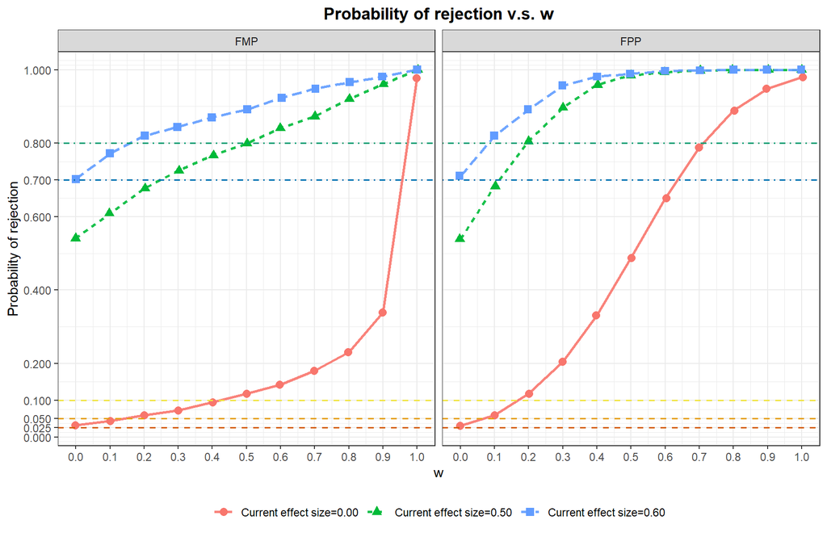

图4.7展示了DIC随$w$的变化：

1. 在无和弱prior-data conflict时（$\tau\in\{0.5, 0.6\},\tau_0=0.6$），对于FMP和FPP方法，DIC的最小值点均为1，此时DIC建议借用全部历史数据；
2. 在强prior-data conflict时（$\tau=0,\tau_0=0.6$），对于FMP方法，DIC的最小值点在$[0, 0.1)$，对于FPP方法，DIC的最小值点在$(0, 0.2)$。

综合基于type I error和power选择$w$的结果，当不确定$w$的取值时，基于DIC选择$w$可能是一个可行方案，提供了不同角度支持$w$选取的合理性。

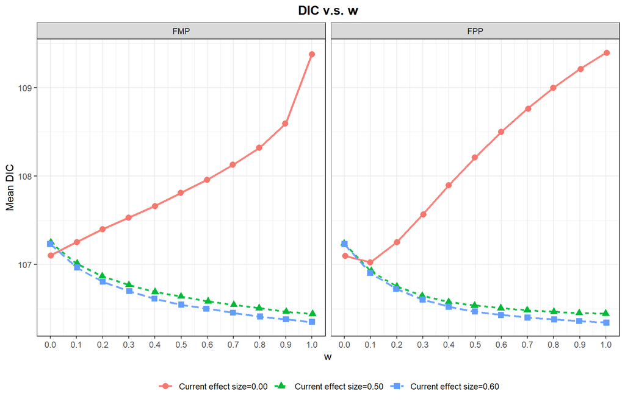

#### 4.1.1.4 数据分析阶段的敏感性分析

本节的模拟试验旨在探索数据分析阶段，如何对$w$的不同取值，进行敏感性分析。

历史数据的治疗效应$\tau_0=0.6$。考虑以下三个场景：

- 场景一：strong prior-data conflict，此时$\tau=0$，样本量等其他参数与第4.1.1.3节相同；
- 场景二：no prior-data conflict，此时$\tau=0.6$，样本量等其他参数与第4.1.1.3节相同；
- 场景三：weak prior-data conflict，此时$\tau=0.5$，样本量等其他参数与第4.1.1.3节相同。

图4.8-4.10展示了三个场景中，两种方法的区间估计随$w$的变化情况（左图为fixed mixture prior方法，右图为fixed power prior方法），表4.4展示发生phase change时$w$的取值和对应的EHSS：

1. 场景一中（图4.8），mixture prior方法在$w\geq0.97$时（对应的EHSS为51.6）支持$H_a:\tau>0$，power prior方法在$w\geq0.5$时（对应的EHSS为49.0）支持$H_a$。Mixture prior的效应估计从不借用的0.015增加到完全借用的0.426，power prior的效应估计从不借用的0.018增加到完全借用的0.423。这些结果表明历史数据与当前研究的治疗效应差别较大，靠近0的$w$可能更加稳健；
2. 场景二中（图4.9），两种方法均没有随$w$的变化发生phase change，且估计随$w$增加几乎无变化，表明历史数据与当前研究的治疗效应几乎没有差异，统计决策对$w$不敏感；
3. 场景三中（图4.10），两种方法均没有随$w$的变化发生phase change。Mixture prior的效应估计从不借用的0.498增加到完全借用的0.568，power prior的效应估计从不借用的0.503增加到完全借用的0.568。这些结果表明历史数据与当前研究的治疗效应差别小，统计决策对$w$不敏感。

综上，若使用第4.1.1.3节中的模拟方法确定$w$的取值，则$w=0.1$时的结果在三种场景下都是稳健的。

Table 4.4: Summary of sensitivity analysis in the three scenarios.

| Historical effect size | Current effect size | Method | Reference $w$ | Reference $\hat\tau$ | Phase change $w$ | Phase change $\hat\tau$ | Phase change EHSS | Fully borrow $w$ | Fully borrow $\hat\tau$ | Fully borrow EHSS |
| --- | --- | --- | --- | --- | --- | --- | --- | --- | --- | --- |
| 0.6 | 0.0 | FMP | 0 | 0.015 | 0.97 | 0.403 | 51.6 | 1 | 0.426 | 91.2 |
|  |  | FPP | 0 | 0.018 | 0.50 | 0.325 | 49.0 | 1 | 0.423 | 91.4 |
|  | 0.5 | FMP | 0 | 0.498 | NA | NA | NA | 1 | 0.568 | 94.6 |
|  |  | FPP | 0 | 0.503 | NA | NA | NA | 1 | 0.568 | 99.4 |
|  | 0.6 | FMP | 0 | 0.601 | NA | NA | NA | 1 | 0.600 | 106.7 |
|  |  | FPP | 0 | 0.600 | NA | NA | NA | 1 | 0.601 | 105.5 |

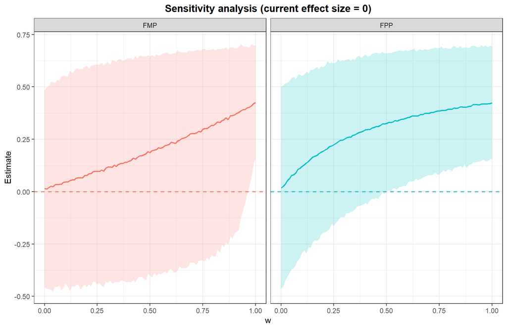

Figure 4.8: Sensitivity analysis for FMP (left) and FPP (right) against $w$ when there is a strong prior-data conflict (current effect size=0.00). The shaded region indicates the 95% credible interval for corresponding method. The reference line indicates the effect size of null hypothesis, i.e., $\tau=0$.

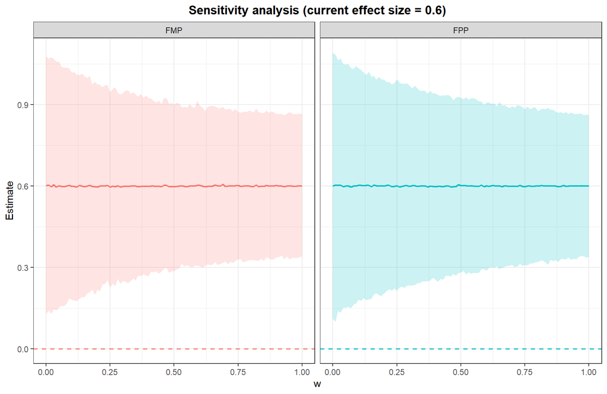

Figure 4.9: Sensitivity analysis for FMP (left) and FPP (right) against $w$ when there is no prior-data conflict (current effect size=0.60). The shaded region indicates the 95% credible interval for corresponding method. The reference line indicates the effect size of null hypothesis, i.e., $\tau=0$.

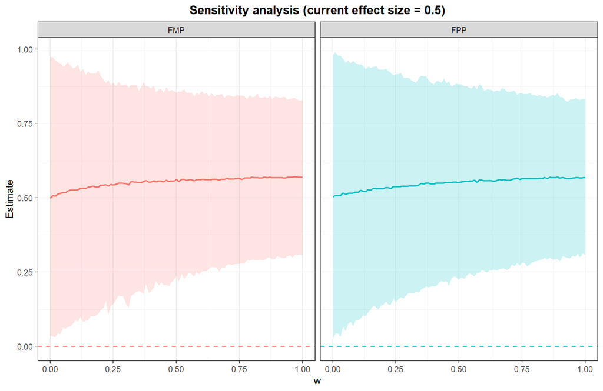

Figure 4.10: Sensitivity analysis for FMP (left) and FPP (right) against $w$ when there is a weak prior-data conflict (current effect size=0.50). The shaded region indicates the 95% credible interval for corresponding method. The reference line indicates the effect size of null hypothesis, i.e., $\tau=0$.

图4.11展示了DIC在三组数据中随$w$的变化，若基于DIC适应性地选取$w$（最小值点）：

1. 场景一下，DIC将会建议mixture prior和power prior分别选择$w=0$和$w=0.1$；
2. 场景二下，DIC将会建议mixture prior和power prior选择$w=1$；
3. 场景三下，DIC将会建议mixture prior和power prior分别选择$w=1$和$w=0.7$。

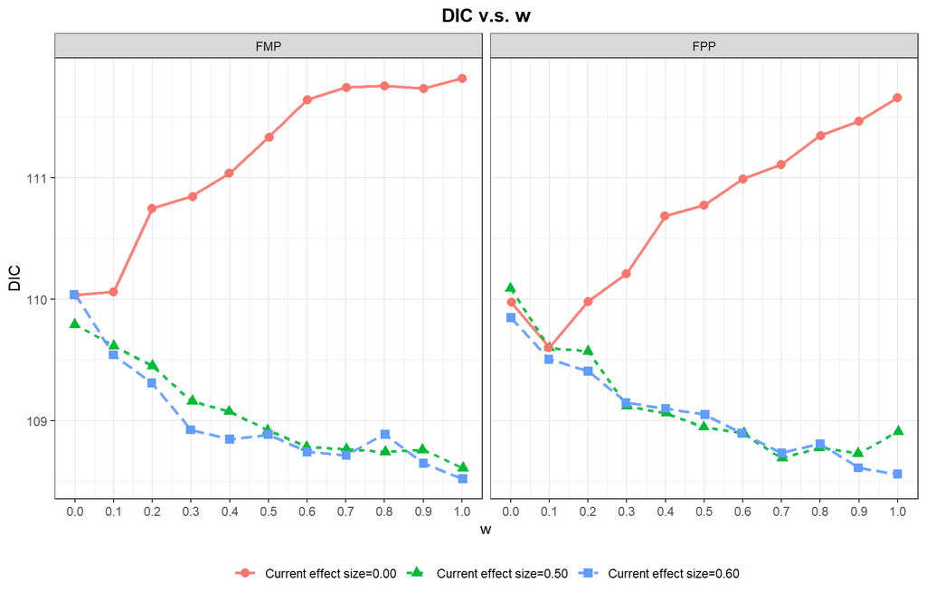

Figure 4.11: DIC for FMP (left) and FPP (right) against $w$ when there is a strong prior-data conflict (current effect size=0.00, red solid lines with round points), no prior-data conflict (current effect size=0.60, blue dashed lines with square points) and weak prior-data conflict (current effect size=0.50, green dashed lines with triangle points).

# 5 To Do List

下表为后续还需完善的工作，除下表列出的内容外，还需考虑：多历史数据信息借用、多臂信息借用等。

Table 5.1: To do list

| 终点 | 模型 | 借用效应值 | 借用对照组 |
| --- | --- | --- | --- |
| 连续型 | ANCOVA | ✓ |  |
| 连续型（重复测量） | MMRM |  |  |
| 二分类（RD） | Binomial likelihood |  |  |
| 二分类（OR） | CMH/Logistic likelihood |  |  |
| 计数型 | Negative binomial model |  |  |
| TTE | Exponential survival model |  |  |

# Reference

Banbeta, Akalu, Joost van Rosmalen, David Dejardin, and Emmanuel Lesaffre. 2019. “Modified Power Prior with Multiple Historical Trials for Binary Endpoints.” *Statistics in Medicine* 38 (7): 1147–69.

Berry, Scott M., Bradley P. Carlin, J. Jack Lee, and Peter Muller. 2010. *Bayesian Adaptive Methods for Clinical Trials*. 1st ed. Boca Raton, FL: Chapman; Hall/CRC.

Friel, N., and A. N. Pettitt. 2008. “Marginal Likelihood Estimation via Power Posteriors.” *Journal of the Royal Statistical Society Series B: Statistical Methodology* 70 (3): 589–607.

Hobbs, Brian P., Bradley P. Carlin, Sumithra J. Mandrekar, and Daniel J. Sargent. 2011. “Hierarchical Commensurate and Power Prior Models for Adaptive Incorporation of Historical Information in Clinical Trials.” *Biometrics* 67 (3): 1047–56.

Hobbs, Brian P., Bradley P. Carlin, and Daniel J. Sargent. 2013. “Adaptive Adjustment of the Randomization Ratio Using Historical Control Data.” *Clinical Trials* 10 (3): 430–40.

Ibrahim, Joseph G., Ming-Hui Chen, and Haitao Chu. 2012. “Bayesian Methods in Clinical Trials: A Bayesian Analysis of ECOG Trials E1684 and E1690.” *BMC Medical Research Methodology* 12 (1): 183.

Ibrahim, Joseph G., Ming-Hui Chen, Yeongjin Gwon, and Fang Chen. 2015. “The Power Prior: Theory and Applications.” *Statistics in Medicine* 34 (28): 3724–49.

Kass, Robert E., and Larry Wasserman. 1995. “A Reference Bayesian Test for Nested Hypotheses and Its Relationship to the Schwarz Criterion.” *Journal of the American Statistical Association* 90 (431): 928–34.

Liang, Faming, and Ick-Hoon Jin. 2013. “A Monte Carlo Metropolis-Hastings Algorithm for Sampling from Distributions with Intractable Normalizing Constants.” *Neural Computation* 25 (8): 2199–2234.

Neuenschwander, Beat, Michael Branson, and David J. Spiegelhalter. 2009. “A Note on the Power Prior.” *Statistics in Medicine* 28 (28): 3562–66.

Robert, Christian P. 2007. *The Bayesian Choice: From Decision-Theoretic Foundations to Computational Implementation*. 2nd ed. New York: Springer.

Schmidli, Heinz, Sandro Gsteiger, Satrajit Roychoudhury, Anthony O’Hagan, David Spiegelhalter, and Beat Neuenschwander. 2014. “Robust Meta-Analytic-Predictive Priors in Clinical Trials with Historical Control Information.” *Biometrics* 70 (4): 1023–32.

Spiegelhalter, David J., Nicola G. Best, Bradley P. Carlin, and Angelika Van Der Linde. 2002. “Bayesian Measures of Model Complexity and Fit.” *Journal of the Royal Statistical Society: Series B (Statistical Methodology)* 64 (4): 583–639.

Yang, Peng, Yuansong Zhao, Lei Nie, Jonathon Vallejo, and Ying Yuan. 2023. “SAM: Self-Adapting Mixture Prior to Dynamically Borrow Information from Historical Data in Clinical Trials.” *Biometrics* 79 (4): 2857–68.

Ye, Keying, Zifei Han, Yuyan Duan, and Tianyu Bai. 2022. “Normalized Power Prior Bayesian Analysis.” *Journal of Statistical Planning and Inference* 216: 29–50.